# DIF: la fonction tam.mml.facet

# Etude des DIFs

On remarque également qu’on obtient une erreur de mesure pour cette estimation. On peut donc z-standardiser les paramètres.

```r
DIFS =
  DIF$xsi.facets %>%
  filter(str_detect(string = facet, pattern = "item:")) %>%
  mutate(z_score = xsi / se.xsi) %>%
  mutate(p.value = pnorm(q = -abs(z_score))) %>%
  tidyr::extract(col = parameter,
                 into = c("item", "selon"),
                 regex = "(.*):(.*)")

DIFS %>% arrange(item)
```

| item | selon | facet | xsi | se.xsi | z_score | p.value |
| --- | --- | --- | --- | --- | --- | --- |
| M1PTI1 | SEX1 | item:SEX | 0.17255776 | 0.02172530 | 7.9427110 | 9.890471e-16 |
| M1PTI1 | SEX2 | item:SEX | -0.17255776 | 0.02172530 | -7.9427110 | 9.890471e-16 |
| M1PTI1 | country1 | item:country | -0.34752966 | 0.02172530 | -15.9965429 | 6.753504e-58 |
| M1PTI1 | country2 | item:country | 0.34752966 | 0.02172530 | 15.9965429 | 6.753504e-58 |
| M1PTI11 | SEX1 | item:SEX | 0.12956968 | 0.02221489 | 5.8325590 | 2.729184e-09 |
| M1PTI11 | SEX2 | item:SEX | -0.12956968 | 0.02221489 | -5.8325590 | 2.729184e-09 |
| M1PTI11 | country1 | item:country | 0.16049271 | 0.02221489 | 7.2245548 | 2.513731e-13 |
| M1PTI11 | country2 | item:country | -0.16049271 | 0.02221489 | -7.2245548 | 2.513731e-13 |
| M1PTI12 | SEX1 | item:SEX | 0.03754630 | 0.02054221 | 1.8277635 | 3.379252e-02 |
| M1PTI12 | SEX2 | item:SEX | -0.03754630 | 0.02054221 | -1.8277635 | 3.379252e-02 |

[output cut: 46 more lines]

graphiquement:

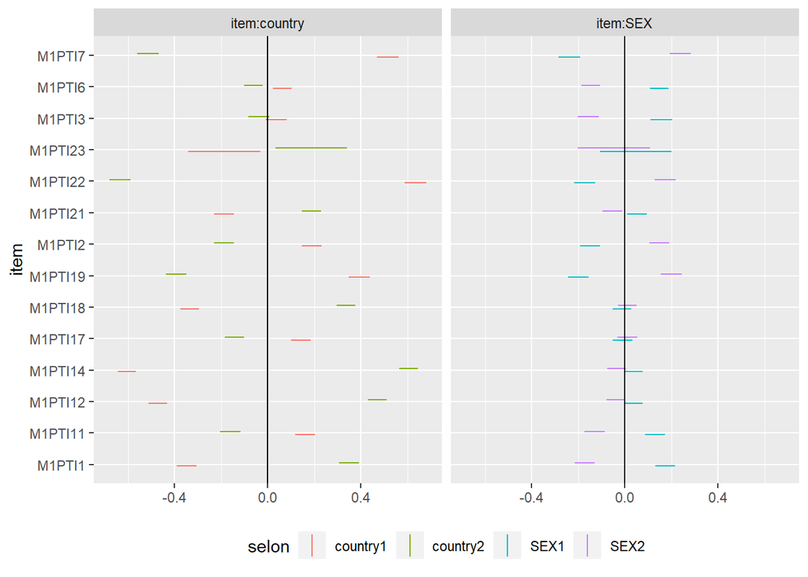

```r
DIFS %>%
  ggplot(mapping = aes(y = item, colour = selon)) +
  geom_linerange(
    mapping = aes(xmin = xsi - 1.96 * se.xsi,
                  xmax = xsi + 1.96 * se.xsi),
    position = position_dodge(width = .2)
  ) +
  geom_vline(xintercept = 0) +
  facet_wrap( ~ facet) +
  theme(legend.position = "bottom")
```

On voit d’abord qu’on a **beaucoup** de DIFs! Est-ce qu’on peut quantifier ces DIFs?

Ici, nous n’avons que deux groupes à chaque fois. On peut donc faire une différence de moyenne, et obtenir une erreur standard selon

$\sigma_{diff} = \sqrt(\sigma_{1}^2+\sigma_{2}^2)$

```r
DIFF_DIFS =
  DIFS %>%
  group_by(item, facet) %>%
  summarise(DIF = max(xsi) - min(xsi),
            DIF_error = sqrt(sum(se.xsi^2)))
DIFF_DIFS
```

| item | facet | DIF | DIF_error |
| --- | --- | --- | --- |
| M1PTI1 | item:country | 0.69505931 | 0.03072421 |
| M1PTI1 | item:SEX | 0.34511552 | 0.03072421 |
| M1PTI11 | item:country | 0.32098543 | 0.03141660 |
| M1PTI11 | item:SEX | 0.25913935 | 0.03141660 |
| M1PTI12 | item:country | 0.94151064 | 0.02905107 |
| M1PTI12 | item:SEX | 0.07509259 | 0.02905107 |
| M1PTI14 | item:country | 1.20800273 | 0.02862303 |
| M1PTI14 | item:SEX | 0.07201214 | 0.02862303 |
| M1PTI17 | item:country | 0.28456513 | 0.03054734 |
| M1PTI17 | item:SEX | 0.02092454 | 0.03054734 |

[output cut: 18 more lines]

soit

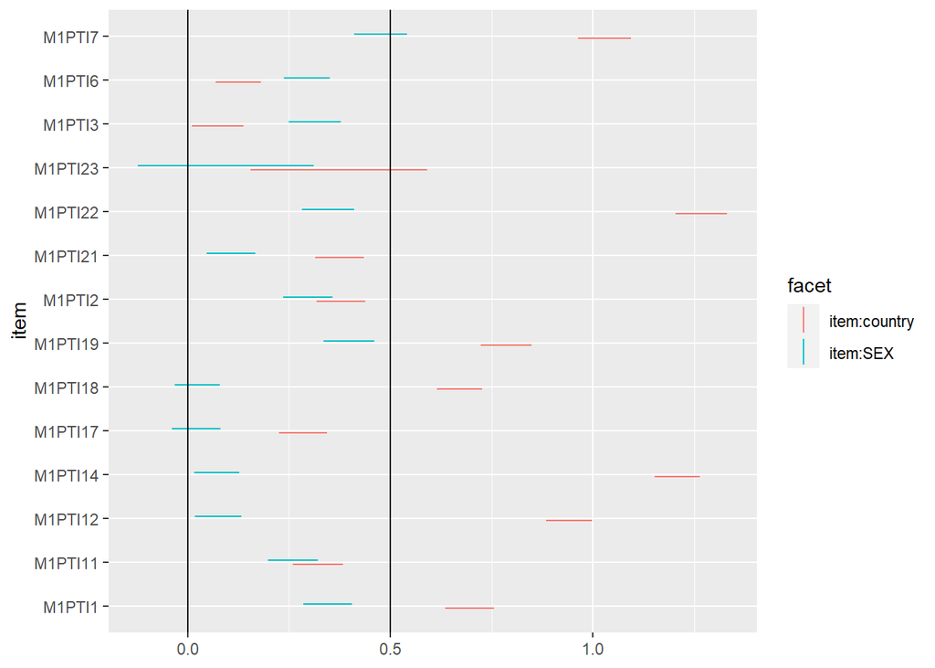

```r
DIFF_DIFS %>%
  ggplot(mapping = aes(y = item, colour = facet)) +
  geom_linerange(
    mapping = aes(xmin = DIF - 1.96 * DIF_error,
                  xmax = DIF + 1.96 * DIF_error),
    position = position_dodge(width = .2)
  ) +
  geom_vline(xintercept = c(0,.5))
```

# Discussion

Cette méthode présente un avantage partagé avec la méthode actuelle, et deux supplémentaires:

- elle est très simple à implémenter, et peu gourmande en calcul.
- elle permet d’obtenir une erreur de mesure, ce qui autorise des calculs de significativité des DIF
- elle permet de réaliser des DIF complexes, sur plusieurs variables en même temps.

Il y a toutefois deux interrogations qui ne sont pas couvertes par cette méthode:

- quid des DIF non uniformes, c’est-à-dire où l’item voit sa discrimination varier entre les groupes?
- elle est intolérante aux valeurs manquantes: il faut que chaque item soit présent dans **chaque groupe**. Cela obligera de toute façon à calculer des DIF 2 à 2 pour les cohortes.
[^1]: https://doi.org/10.1207/s15327841mpee1004_1
[^2]: The First International Mathematics Study, conducted in the 1960s, involved 13-year-old students from 10 countries and students in their last year of secondary school from 10 countries: https://nces.ed.gov/pubs92/web/92011.asp